# Pre Processing Metrics Benchmarking

This notebook is a follow up notebook to previous benchmarking done in `02-compare-quants.RMD`. Here, we have used the most recent release of [Salmon](https://github.com/COMBINE-lab/salmon/releases/tag/v1.4.0) and [Cellranger 6.0.0](https://support.10xgenomics.com/single-cell-gene-expression/software/pipelines/latest/release-notes), and included the new [Alevin-Fry](https://alevin-fry.readthedocs.io/en/latest/getting_started.html) method. Alevin-Fry can use either a selective alignment strategy or pseudoalignment strategy (with the `--sketch` flag),so here we are testing both strategies. Alevin-Fry also can use the 10X whitelist for barcode assignment rather than generating the putative whitelist using the `--unfiltered` flag, so we have also included that in our tests.

The resolution currently used for Alevin-Fry is the Full resolution. See the documentation for more information on different options for resolution that could be used.

The goal of this notebook is to compare the quantification performed by each tool across the samples we have currently run. Thus far, we have 4 10Xv3 single cell RNA-seq samples that have been run on all tools, SCPCR000003, SCPCR000006, SCPCR000126, and SCPCR000127. We also have 2 10Xv3.1 single nucleus RNA-seq samples that have been run on all tools, SCPCR000118 and SCPCR000119. All the snRNA-seq samples have been run using either the pre-mRNA index (spliced_intron_ label for alevin and kallisto) or the mRNA index (spliced_ label for alevin and kallisto). One thing to note is that the spliced_ index is different from the previously used index’s with the single cell RNA seq samples in that it was created by grabbing the genomic regions corresponding to spliced cDNA only from the ensembl gtf, rather than taking the cDNA.fasta directly from ensembl.

## Setup

### Load Libraries for import

```r
library(tidyverse)
library(ggplot2)
library(SingleCellExperiment)
library(forcats)
```

### File and Directory Setup

```r
# where all the data lives after running 01-import-quant-data.Rmd
import_dir <- file.path('data')

quant_info_file <- file.path(import_dir, 'quant_info.tsv')

alevin_rds <- file.path(import_dir, 'alevin_sces.rds')
alevin_fry_rds <- file.path(import_dir, 'alevin_fry_sces.rds')
alevin_fry_sketch_rds <- file.path(import_dir, 'alevin_fry_sketch_sces.rds')
alevin_fry_unfiltered_rds <- file.path(import_dir, 'alevin_fry_unfiltered_sces.rds')
alevin_fry_unfiltered_sketch_rds <- file.path(import_dir, 'alevin_fry_unfiltered_sketch_sces.rds')
kallisto_rds <- file.path(import_dir, 'kallisto_sces.rds')
cellranger_rds <- file.path(import_dir, 'cellranger_sces.rds')
```

```r
# read in quant info file created in 01-import-quant-data.Rmd
quant_info <- readr::read_tsv(quant_info_file)
# make sure that the tool is labeled as alevin_fry_sketch/ unfiltered to distinguish from regular alevin_fry for later
quant_info[which(quant_info$alevin_alignment == "sketch" & quant_info$alevin_permit_list != "unfiltered"),"tool"] <- "alevin_fry_sketch"
quant_info[which(quant_info$alevin_alignment == "salign" & quant_info$alevin_permit_list == "unfiltered"), "tool"] <- "alevin_fry_unfiltered"
quant_info[which(quant_info$alevin_alignment == "sketch" & quant_info$alevin_permit_list == "unfiltered"), "tool"] <- "alevin_fry_unfiltered_sketch"
```

```r
# Each RDS file contains a SingleCellExperiment
alevin_sces <- readr::read_rds(alevin_rds)
alevin_fry_sces <- readr::read_rds(alevin_fry_rds)
alevin_fry_sketch_sces <- readr::read_rds(alevin_fry_sketch_rds)
alevin_fry_unfiltered_sces <- readr::read_rds(alevin_fry_unfiltered_rds)
alevin_fry_unfiltered_sketch_sces <- readr::read_rds(alevin_fry_unfiltered_sketch_rds)
kallisto_sces <- readr::read_rds(kallisto_rds)
cellranger_sces <- readr::read_rds(cellranger_rds)
```

```r
## get all annotation data from S3
annotation_dir <- file.path(import_dir, "annotation")

## get mitochondrial gene list from s3
annotation_files_s3 <-
  's3://nextflow-ccdl-data/reference/homo_sapiens/ensembl-100/annotation/'

sync_call <- paste('aws s3 sync', annotation_files_s3, annotation_dir)
system(sync_call, ignore.stdout = TRUE)
```

```r
mito_file <- file.path(annotation_dir, "Homo_sapiens.ensembl.100.mitogenes.txt")

mito_genes <- readr::read_tsv(mito_file, col_names = "gene_id")
mito_genes <- mito_genes %>%
  pull(gene_id)
```

## Add QC Metrics

```r
addPerCellQC_mito <- function(sce, mito = mito_genes){
  # add per cell QC with mitochondrial genes separately for later comparisons
  scater::addPerCellQC(
    sce,
    subsets = list(mito = mito[mito %in% rownames(sce)])
  )
}
```

```r
alevin_sces <- alevin_sces %>%
  purrr::map(addPerCellQC_mito)

alevin_fry_sces <- alevin_fry_sces %>%
  purrr::map(addPerCellQC_mito)

alevin_fry_sketch_sces <- alevin_fry_sketch_sces %>%
  purrr::map(addPerCellQC_mito)

alevin_fry_unfiltered_sces <- alevin_fry_unfiltered_sces %>%
  purrr::map(addPerCellQC_mito)

alevin_fry_unfiltered_sketch_sces <- alevin_fry_unfiltered_sketch_sces %>%
  purrr::map(addPerCellQC_mito)

kallisto_sces <- kallisto_sces %>%
  purrr::map(addPerCellQC_mito)

cellranger_sces <- cellranger_sces %>%
  purrr::map(addPerCellQC_mito)
```

```r
## merge all QC output into one data frame to work with for plotting comparisons
celldata_to_df <- function(sce){
  # extract the column (cell) summary data from a SCE,
  # convert to data frame and move cell id to a column
  as.data.frame(colData(sce)) %>%
  tibble::rownames_to_column(var = "cell_id") %>%
    # add a column to get # of cells detected in that sample
    mutate(cells_detected = ncol(sce))
}

alevin_cell_qc <- alevin_sces %>%
  purrr::map_df(celldata_to_df, .id = "quant_id")

alevin_fry_cell_qc <- alevin_fry_sces %>%
  purrr::map_df(celldata_to_df, .id = "quant_id")

alevin_fry_sketch_cell_qc <- alevin_fry_sketch_sces %>%
  purrr::map_df(celldata_to_df, .id = "quant_id")

alevin_fry_unfiltered_cell_qc <- alevin_fry_unfiltered_sces %>%
  purrr::map_df(celldata_to_df, .id = "quant_id")

alevin_fry_unfiltered_sketch_cell_qc <- alevin_fry_unfiltered_sketch_sces %>%
  purrr::map_df(celldata_to_df, .id = "quant_id")

kallisto_cell_qc <- kallisto_sces %>%
  purrr::map_df(celldata_to_df, .id = "quant_id")

cellranger_cell_qc <- cellranger_sces %>%
  purrr::map_df(celldata_to_df, .id = "quant_id")

# combine all the data frames into one
cell_qc <- dplyr::bind_rows(
  alevin = alevin_cell_qc,
  alevin_fry = alevin_fry_cell_qc,
  alevin_fry_sketch = alevin_fry_sketch_cell_qc,
  alevin_fry_unfiltered = alevin_fry_unfiltered_cell_qc,
  alevin_fry_unfiltered_sketch = alevin_fry_unfiltered_sketch_cell_qc,
  kallisto = kallisto_cell_qc,
  cellranger = cellranger_cell_qc,
  .id = "tool"
) %>%
  dplyr::left_join(quant_info,
                   by = c("tool" = "tool",
                          "quant_id" = "quant_dir"))
```

## Comparison of QC Metrics across all tools

### Per Cell QC

Let’s first start by taking a look at some general information across all of our tools and how consistent each of these metrics is for all four of the samples. Here are the metrics we want to look at:

- Total number of cells detected
- Mitochondrial content/ cell
- Number of UMIs/cell
- Number of Genes/cell

```r
## make new data frame with mean of cells detected and standard dev
cells_detected_stats <- cell_qc %>%
  group_by(sample, tool) %>%
  summarise(cells_detected = mean(cells_detected))
cells_detected_stats
```

| sample | tool | cells_detected |
| --- | --- | --- |
| SCPCR000003 | alevin | 6654.0000 |
| SCPCR000003 | alevin_fry | 4312.0000 |
| SCPCR000003 | alevin_fry_sketch | 4333.0000 |
| SCPCR000003 | alevin_fry_unfiltered | 143119.0000 |
| SCPCR000003 | alevin_fry_unfiltered_sketch | 169642.0000 |
| SCPCR000003 | cellranger | 1178.0000 |
| SCPCR000003 | kallisto | 405.0000 |
| SCPCR000006 | alevin | 3153.0000 |
| SCPCR000006 | alevin_fry | 1984.0000 |
| SCPCR000006 | alevin_fry_sketch | 2006.0000 |

[output cut: 32 more lines]

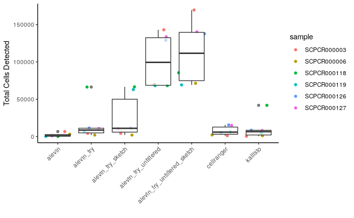

```r
## first look at cells detected
ggplot(cells_detected_stats, aes(x = tool, y = cells_detected)) +
  geom_jitter(mapping = aes(color = sample)) +
  geom_boxplot(alpha = 0.6) +
  theme_classic() +
  ylab("Total Cells Detected") +
  xlab("") +
  theme(axis.text.x = element_text(angle = 45, hjust = 1))
```

Based on this, I am extremely concerned by the amount of cells that Alevin-fry `--sketch` and `--unfiltered` is detecting. It looks like for every sample, the `--unfiltered` option is detecting a ton more cells than alevin-fry using the `--knee-distance` rather than less cells which is what I would have expected. I am not entirely sure what the explanation for this is…

Let’s take a look at the mitochondrial content per cell across the tools and see if we see variation there.

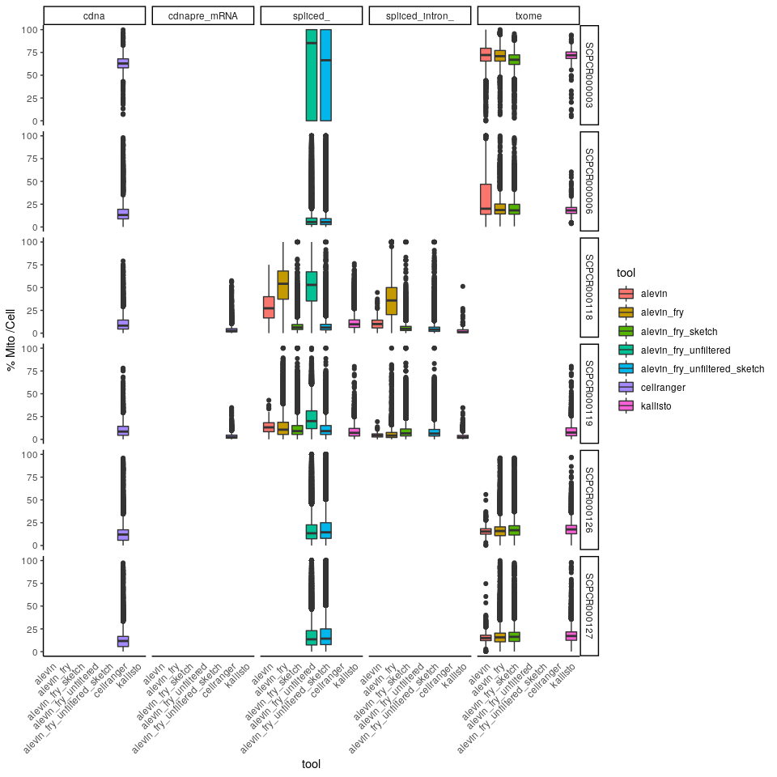

```r
ggplot(cell_qc, aes(x = tool, y = subsets_mito_percent, fill = tool)) +
  geom_boxplot() +
  facet_grid(sample ~ index_type) +
  theme_classic() +
  ylab("% Mito /Cell") +
  theme(axis.ticks.x = element_blank(), axis.text.x = element_text(angle = 45, hjust = 1))
```

It looks like SCPCR000003 is a very poor sample across all tools and has a lot of dead cells. It might be a good idea to remove that from our comparisons and not consider this for benchmarking. Additionally, it looks like we can see that SCPCR000006 (scRNAseq) and SCPCR000118 (snRNAseq) vary across tools, but the other three samples tend to be fairly consistent.

```r
# remove SCPCR000003 from cell_qc for the rest of the plotting
cell_qc_filter <- cell_qc %>%
  dplyr::filter(sample != "SCPCR000003")
```

Now let’s look at the number of UMI’s detected/cell that we’ve removed our outlier sample.

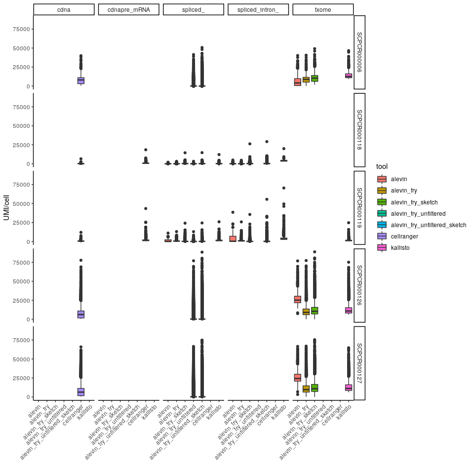

```r
# number of UMI's/sample
ggplot(cell_qc_filter, aes(x = tool, y = sum, fill = tool)) +
  geom_boxplot() +
  facet_grid(sample ~ index_type) +
  theme_classic() +
  theme(axis.text.x = element_text(angle = 45, hjust = 1)) +
  ylab("UMI/cell") +
  xlab("")
```

At first glance, SCPCR000118 and SCPCR000119 (the single nucleus RNA-seq samples) have very low values of UMI/cell. Is this because these samples are poor quality? Or is it a problem with the index? However, the samples don’t look any better with cellranger so it could be a sample issue or a common feature of snRNA-seq samples.

Let’s separate our plots to look at single cell vs. single nucleus RNA-seq.

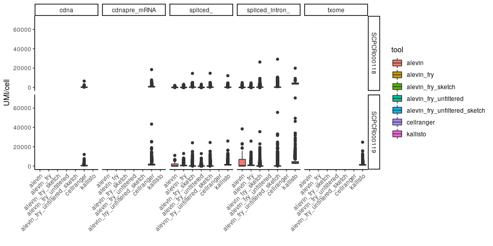

```r
# first look at single nucleus samples only
cell_qc_filter %>%
  filter(seq_unit == "nucleus") %>%
  ggplot(aes(x = tool, y = sum, fill = tool)) +
  geom_boxplot() +
  facet_grid(sample ~ index_type) +
  theme_classic() +
  theme(axis.text.x = element_text(angle = 45, hjust = 1)) +
  ylab("UMI/cell") +
  xlab("")
```

In general, it looks like SCPCR000118 has lower coverage than 119. Cellranger and Kallisto (with the pre mRNA/spliced_intron index) actually seem to be have the highest UMIs/cell. In general, there is quite low coverage so it is hard to make a lot of big conclusions here.

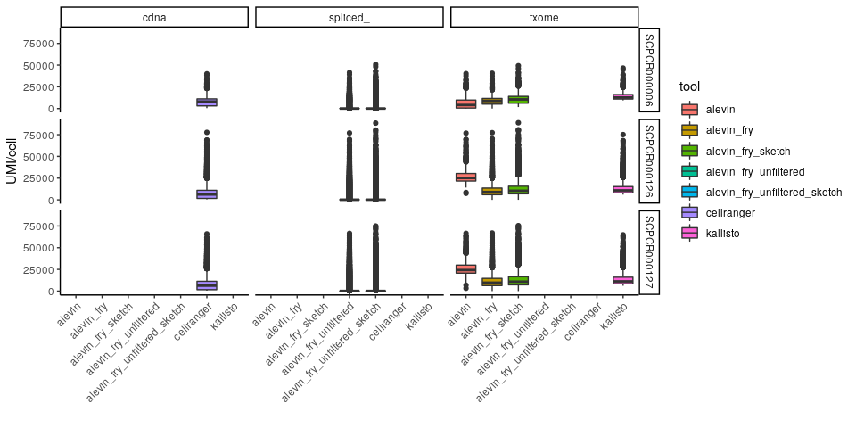

```r
# single cell samples only
cell_qc_filter %>%
  filter(seq_unit == "cell") %>%
  ggplot(aes(x = tool, y = sum, fill = tool)) +
  geom_boxplot() +
  facet_grid(sample ~ index_type) +
  theme_classic() +
  theme(axis.text.x = element_text(angle = 45, hjust = 1)) +
  ylab("UMI/cell") +
  xlab("")
```

I think keeping the single cell and single nuclei samples separate is helpful for visualization so I’m going to keep them separate from here on out.

Now let’s look at genes/cell?

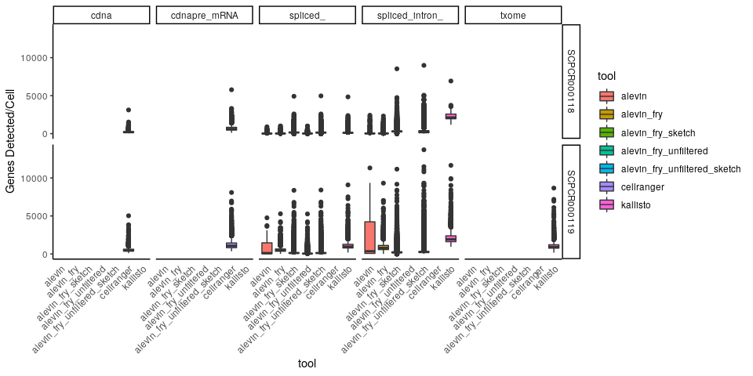

```r
cell_qc_filter %>%
  filter(seq_unit == "nucleus") %>%
  ggplot(aes(x = tool, y = detected, fill = tool)) +
  geom_boxplot() +
  facet_grid(sample ~ index_type) +
  theme_classic() +
  ylab("Genes Detected/Cell") +
  theme(axis.ticks.x = element_blank(), axis.text.x = element_text(angle = 45, hjust = 1))
```

Here, we see a bit more variation in genes/cell for the single nucleus samples than we did with the UMI/cell.

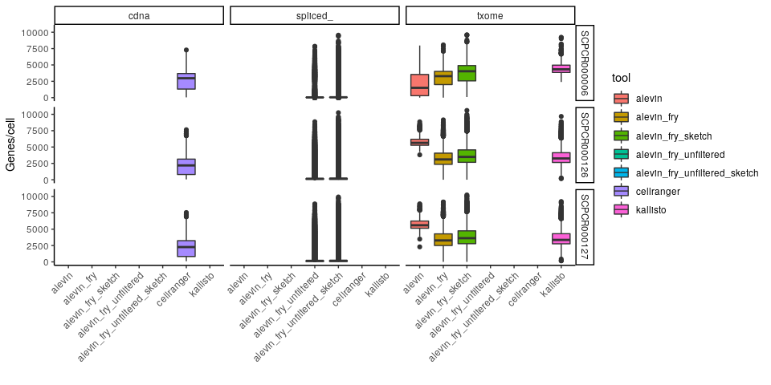

```r
# single cell samples only
cell_qc_filter %>%
  filter(seq_unit == "cell") %>%
  ggplot(aes(x = tool, y = detected, fill = tool)) +
  geom_boxplot() +
  facet_grid(sample ~ index_type) +
  theme_classic() +
  theme(axis.text.x = element_text(angle = 45, hjust = 1)) +
  ylab("Genes/cell") +
  xlab("")
```

Here we are seeing similar trends in genes/cell as we did with UMI/cell for the single cell samples. We do see that alevin tends to report high genes/cell in all but 1 of the scRNA-seq samples. That same sample was the one that alevin also showed high mito content for, so perhaps that is why 006 is not as high for alevin. In general, cellranger and kallisto tend to do better with the snRNA-seq samples, but not as high in scRNA-seq samples. For single cell RNA seq there is a lot more consistency across the tools.

### Shared Cell QC, No Minimum Gene Coverage

What if we just look at cells that are found in all of the tools?

```r
cell_only_qc_filter <- cell_qc_filter %>%
  filter(seq_unit == "cell")
nucleus_qc_filter <- cell_qc_filter %>%
  filter(seq_unit == "nucleus")
```

```r
# filter for cells that are found in all 7 combinations of tools + index's
cell_counts <- cell_only_qc_filter %>%
  dplyr::count(cell_id, sample)

common_cells <- cell_counts %>%
  dplyr::filter(n == 7) %>%
  dplyr::pull(cell_id)

cell_only_qc_common <- cell_only_qc_filter %>%
  dplyr::filter(
    (cell_id %in% common_cells)
  )
```

```r
# filter for cells that are found in all 13 combinations of tools + index's for nucleus
# keep in mind that we have one sample (SCPCR000119) that was run on 14 combinations (!) and we need to filter accordingly
nuclei_counts <- nucleus_qc_filter %>%
  dplyr::count(cell_id, sample)

common_nuclei_118 <- nuclei_counts %>%
  dplyr::filter(n == 13) %>%
  dplyr::pull(cell_id)

common_nuclei_119 <- nuclei_counts %>%
  dplyr::filter(n==14) %>%
  dplyr::pull(cell_id)

nucleus_qc_common <- nucleus_qc_filter %>%
  dplyr::filter(
    (cell_id %in% c(common_nuclei_118, common_nuclei_119))
  )
```

Now what happens to our mito content, UMI/cell, and genes/cell?

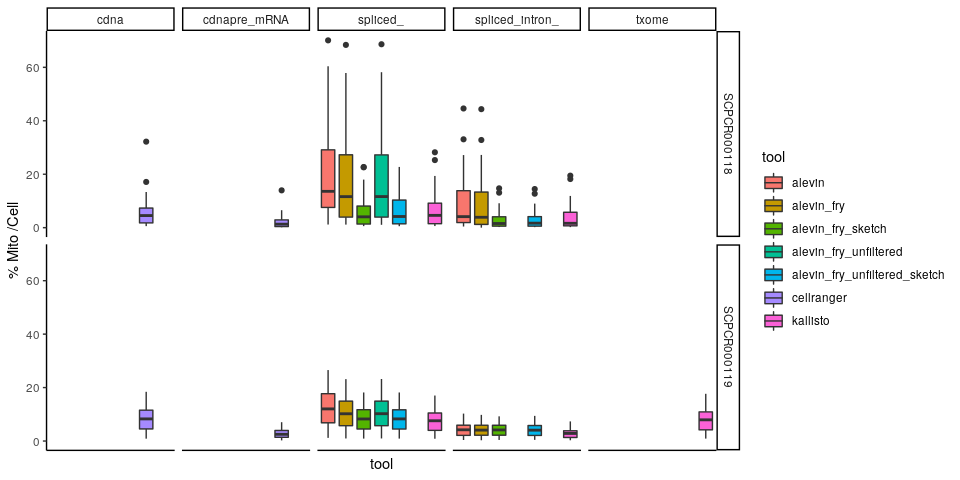

```r
# mito comparison across shared cells only of all runs
# nucleus samples first
ggplot(nucleus_qc_common, aes(x = tool, y = subsets_mito_percent, fill = tool)) +
  geom_boxplot() +
  facet_grid(sample ~ index_type) +
  theme_classic() +
  ylab("% Mito /Cell") +
  theme(axis.ticks.x = element_blank(), axis.text.x = element_blank())
```

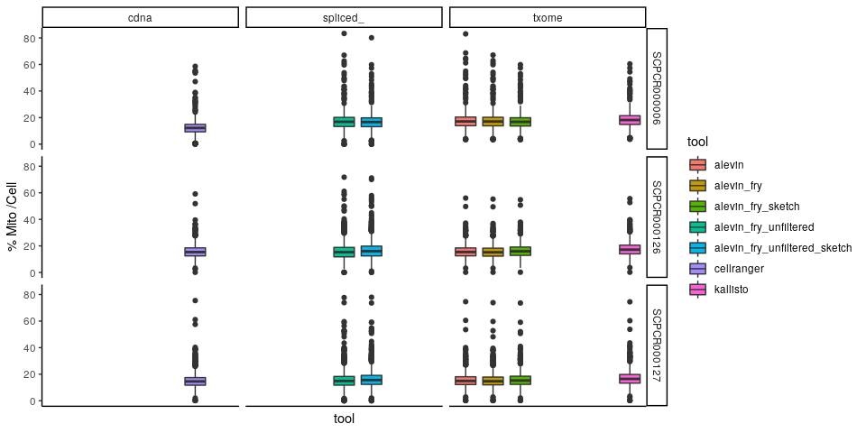

```r
# single cell
ggplot(cell_only_qc_common, aes(x = tool, y = subsets_mito_percent, fill = tool)) +
  geom_boxplot() +
  facet_grid(sample ~ index_type) +
  theme_classic() +
  ylab("% Mito /Cell") +
  theme(axis.ticks.x = element_blank(), axis.text.x = element_blank())
```

In looking at this plot, the mito content of SCPCR000118 is very high in the alevin tools, but not the other tools. The other samples show mostly consistent results across each sample and each tool.

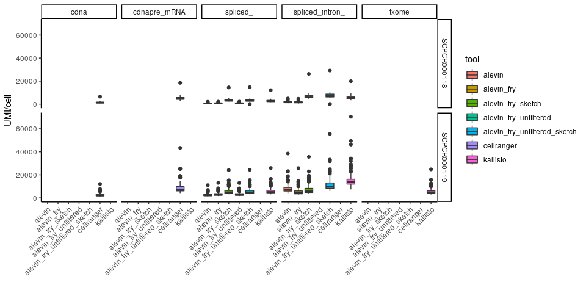

```r
# number of UMI's/sample in shared cells only
# first look at single nucleus samples only
ggplot(nucleus_qc_common, aes(x = tool, y = sum, fill = tool)) +
  geom_boxplot() +
  facet_grid(sample ~ index_type) +
  theme_classic() +
  theme(axis.text.x = element_text(angle = 45, hjust = 1)) +
  ylab("UMI/cell") +
  xlab("")
```

Interestingly, when we look at shared cells only, we see that there is clearly higher UMIs/cell in the snRNA-seq samples with kallisto, in particular with using the spliced_intron index. The next highest coverage looks like it is observed in cellranger (?) and we see a bump in UMIs/cell when looking at the pre-mRNA index vs. the cDNA index alone. The Alevin-fry sketch and unfiltered with the spliced intron index actually might be higher than cellranger.

What about the single cell samples?

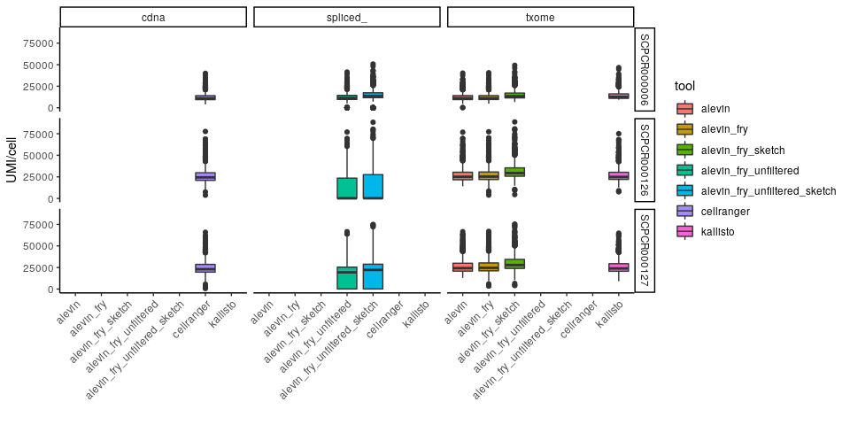

```r
# number of UMI's/sample in shared cells only
# scRNA seq samples
ggplot(cell_only_qc_common, aes(x = tool, y = sum, fill = tool)) +
  geom_boxplot() +
  facet_grid(sample ~ index_type) +
  theme_classic() +
  theme(axis.text.x = element_text(angle = 45, hjust = 1)) +
  ylab("UMI/cell") +
  xlab("")
```

So it looks like there is generally uniform coverage across all the samples in all tools with the exception of alevin-fry unfiltered. Alevin-fry –sketch actually looks like it is edging out above the rest.  
Kallisto doesn’t appear to have the advantage here like it does in the single nuclei samples.

Is that same pattern consistent in genes/cell in shared cells only?

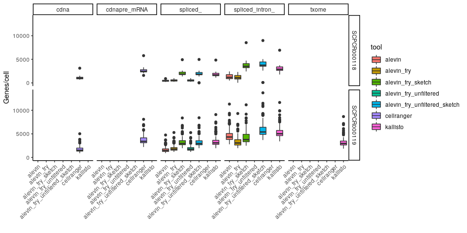

```r
# genes/cell in shared cells only
# single nucleus samples only
ggplot(nucleus_qc_common, aes(x = tool, y = detected, fill = tool)) +
  geom_boxplot() +
  facet_grid(sample ~ index_type) +
  theme_classic() +
  theme(axis.text.x = element_text(angle = 45, hjust = 1)) +
  ylab("Genes/cell") +
  xlab("")
```

So no longer is kallisto in the lead, with alevin-fry sketch and alevin-fry unfiltered sketch starting to increase. Something that seems very clear is the advantage of using the pre mRNA or spliced_intron index for single nuclei samples. I am still worried about the cell numbers for alevin-fry –unfiltered and am not sure what to think about that…

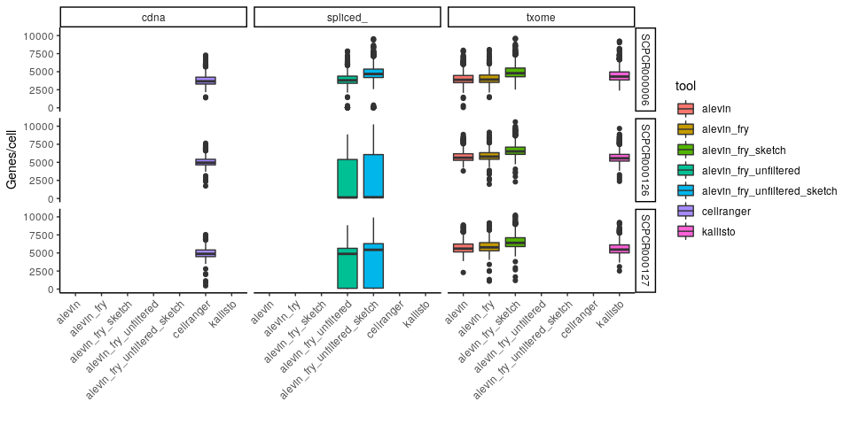

```r
# single cell samples only
ggplot(cell_only_qc_common, aes(x = tool, y = detected, fill = tool)) +
  geom_boxplot() +
  facet_grid(sample ~ index_type) +
  theme_classic() +
  theme(axis.text.x = element_text(angle = 45, hjust = 1)) +
  ylab("Genes/cell") +
  xlab("")
```

We see a similar trend to UMIs/cell, with alevin alevin-fry starting to edge out as being the highest.

Let’s do the same thing, but only look at genes above a certain threshold. Is alevin-fry still giving us the highest genes/cell across shared cells in single cell and kallisto/alevin-fry-unfiltered-sketch the highest in single nucleus?

```r
perCellQCMetrics_threshold <- function(sce, mito = mito_genes, threshold){
  # add per cell QC with mitochondrial genes separately for later comparisons
  scater::perCellQCMetrics(
    sce,
    threshold = threshold
  )
}
```

```r
alevin_QC_metrics <- alevin_sces %>%
  purrr::map(perCellQCMetrics_threshold, threshold = 5)

alevin_fry_QC_metrics <- alevin_fry_sces %>%
  purrr::map(perCellQCMetrics_threshold, threshold = 5)

alevin_fry_sketch_QC_metrics <- alevin_fry_sketch_sces %>%
  purrr::map(perCellQCMetrics_threshold, threshold = 5)

alevin_fry_unfiltered_QC_metrics <- alevin_fry_unfiltered_sces %>%
  purrr::map(perCellQCMetrics_threshold, threshold = 5)

alevin_fry_unfiltered_sketch_QC_metrics <- alevin_fry_unfiltered_sketch_sces %>%
  purrr::map(perCellQCMetrics_threshold, threshold = 5)

kallisto_QC_metrics <- kallisto_sces %>%
  purrr::map(perCellQCMetrics_threshold, threshold = 5)

cellranger_QC_metrics <- cellranger_sces %>%
  purrr::map(perCellQCMetrics_threshold, threshold = 5)
```

```r
## merge all QC output into one data frame to work with for plotting comparisons
QC_metrics_to_df <- function(QC_metrics){
  # move cell id to a column
  as.data.frame(QC_metrics) %>%
  tibble::rownames_to_column(var = "cell_id") %>%
    # add a column to get # of cells detected in that sample
    mutate(cells_detected = ncol(QC_metrics))
}


alevin_cell_qc_thresh_5 <- alevin_QC_metrics %>%
  purrr::map_df(QC_metrics_to_df, .id = "quant_id")

alevin_fry_cell_qc_thresh_5 <- alevin_fry_QC_metrics %>%
  purrr::map_df(QC_metrics_to_df, .id = "quant_id")

alevin_fry_sketch_cell_qc_thresh_5 <- alevin_fry_sketch_QC_metrics %>%
  purrr::map_df(QC_metrics_to_df, .id = "quant_id")

alevin_fry_unfiltered_cell_qc_thresh_5 <- alevin_fry_unfiltered_QC_metrics %>%
  purrr::map_df(QC_metrics_to_df, .id = "quant_id")

alevin_fry_unfiltered_sketch_cell_qc_thresh_5 <- alevin_fry_unfiltered_sketch_QC_metrics %>%
  purrr::map_df(QC_metrics_to_df, .id = "quant_id")

kallisto_cell_qc_thresh_5 <- kallisto_QC_metrics %>%
  purrr::map_df(QC_metrics_to_df, .id = "quant_id")

cellranger_cell_qc_thresh_5 <- cellranger_QC_metrics %>%
  purrr::map_df(QC_metrics_to_df, .id = "quant_id")

# combine all the data frames into one
cell_qc_thresh_5 <- dplyr::bind_rows(
  alevin = alevin_cell_qc_thresh_5,
  alevin_fry = alevin_fry_cell_qc_thresh_5,
  alevin_fry_sketch = alevin_fry_sketch_cell_qc_thresh_5,
  alevin_fry_unfiltered = alevin_fry_unfiltered_cell_qc_thresh_5,
  alevin_fry_unfiltered_sketch = alevin_fry_unfiltered_sketch_cell_qc_thresh_5,
  kallisto = kallisto_cell_qc_thresh_5,
  cellranger = cellranger_cell_qc_thresh_5,
  .id = "tool"
) %>%
  dplyr::left_join(quant_info,
                   by = c("tool" = "tool",
                          "quant_id" = "quant_dir"))
```

```r
#first remove SCPCR000003
cell_qc_thresh_5 <- cell_qc_thresh_5 %>%
  dplyr::filter(sample != "SCPCR000003")
```

```r
cell_only_qc_thresh_5 <- cell_qc_thresh_5 %>%
  filter(seq_unit == "cell")
nucleus_qc_thresh_5 <- cell_qc_thresh_5 %>%
  filter(seq_unit == "nucleus")
```

```r
# filter for cells that are found in all 7 combinations of tools + index's
cell_counts_thresh_5 <- cell_only_qc_thresh_5 %>%
  dplyr::count(cell_id, sample)

common_cells_thresh_5 <- cell_counts_thresh_5 %>%
  dplyr::filter(n == 7) %>%
  dplyr::pull(cell_id)

cell_qc_common_thresh_5 <- cell_only_qc_thresh_5 %>%
  dplyr::filter(
    (cell_id %in% common_cells_thresh_5)
  )
```

```r
# filter for cells that are found in all 13 combinations of tools + index's for nucleus
# keep in mind that we have one sample (SCPCR000119) that was run on 14 combinations (!) and we need to filter accordingly
nuclei_counts_thresh_5 <- nucleus_qc_thresh_5 %>%
  dplyr::count(cell_id, sample)

common_nuclei_118_thresh_5 <- nuclei_counts_thresh_5 %>%
  dplyr::filter(n == 13) %>%
  dplyr::pull(cell_id)

common_nuclei_119_thresh_5 <- nuclei_counts_thresh_5 %>%
  dplyr::filter(n==14) %>%
  dplyr::pull(cell_id)

nucleus_qc_common_thresh_5 <- nucleus_qc_thresh_5 %>%
  dplyr::filter(
    (cell_id %in% common_nuclei_118_thresh_5) | (cell_id %in% common_nuclei_119_thresh_5)
  )
```

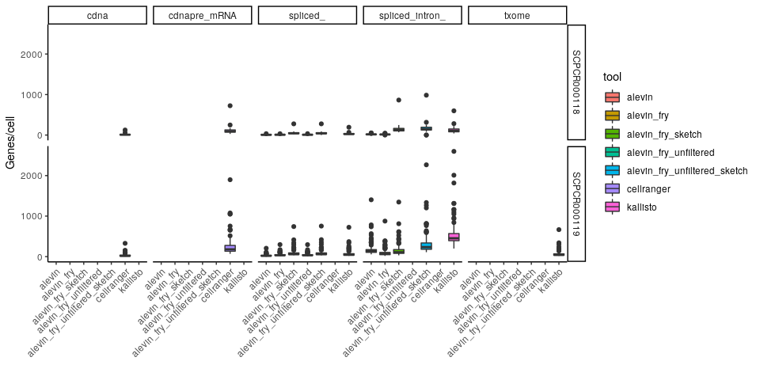

```r
# do we see a change in the number of genes/cell across tools if we remove low covered genes?
# single nucleus samples
 ggplot(nucleus_qc_common_thresh_5, aes(x = tool, y = detected, fill = tool)) +
  geom_boxplot() +
  facet_grid(sample ~ index_type) +
  theme_classic() +
  theme(axis.text.x = element_text(angle = 45, hjust = 1)) +
  ylab("Genes/cell") +
  xlab("")
```

Interestingly, when we remove lowly covered genes in the single nuclei samples, the increased genes/cell seen in alevin-fry sketch and sketch-unfiltered is no longer apparent. We now see that kallisto with the spliced_intron index has the highest genes/cell.

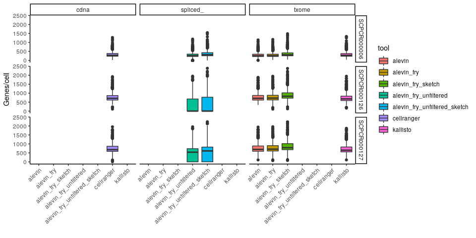

```r
# single cell samples
ggplot(cell_qc_common_thresh_5, aes(x = tool, y = detected, fill = tool)) +
  geom_boxplot() +
  facet_grid(sample ~ index_type) +
  theme_classic() +
  theme(axis.text.x = element_text(angle = 45, hjust = 1)) +
  ylab("Genes/cell") +
  xlab("")
```

Although the total number of genes detected and the range decreases across all cells, it appears that lowly covered genes do not affect the distribution of genes/cell in the single cell samples but do for the single nuclei samples. This could very well be an effect of the lower capture seen in single nuclei samples.

Now that we’ve looked at the stats for the shared cells, let’s look and see how many cells are shared across which tools.

```r
# spread table for comparisons
cell_qc_common_cor <- cell_only_qc_common %>%
  # spread the mean expression stats to one column per caller
  tidyr::pivot_wider(id_cols = c(cell_id, sample),
                     names_from = tool,
                     values_from = sum) %>%
  # drop rows with NA values to ease correlation calculations
  tidyr::drop_na()

nucleus_qc_common_cor <- nucleus_qc_common %>%
  tidyr::pivot_wider(id_cols = c(cell_id, sample),
                     names_from = c("tool", "index_type"),
                     values_from = sum) %>%
  # remove column with kallisto before dropping NA otherwise we will lose sample 118
  dplyr::select(-kallisto_txome) %>%
  tidyr::drop_na()
```

```r
cell_qc_common_cor %>%
  dplyr::group_by(sample) %>%
  dplyr::summarize(
    cr_al_cor = cor(cellranger, alevin, method = "spearman"),
    cr_al_fry_cor =cor(cellranger, alevin_fry, method = "spearman"),
    cr_al_fry_sketch_cor = cor(cellranger, alevin_fry_sketch, method = "spearman"),
    cr_al_fry_unfiltered_cor = cor(cellranger, alevin_fry_unfiltered, method = "spearman"),
    cr_al_fry_unfiltered_sketch_cor = cor(cellranger, alevin_fry_unfiltered_sketch, method = "spearman"),
    cr_ka_cor = cor(cellranger, kallisto, method = "spearman")
  )
```

|  | sample | cr_al_cor | cr_al_fry_cor | cr_al_fry_sketch_cor | cr_al_fry_unfiltered_cor | cr_al_fry_unfiltered_sketch_cor | cr_ka_cor |
| --- | --- | --- | --- | --- | --- | --- | --- |
| 1 | SCPCR000006 | 0.9913507 | 0.9907381 | 0.9882672 | 0.9907507 | 0.9855540 | 0.9778167 |
| 2 | SCPCR000126 | 0.9849965 | 0.9918406 | 0.9850815 | 0.9917953 | 0.9851922 | 0.9701705 |
| 3 | SCPCR000127 | 0.9937571 | 0.9939131 | 0.9877820 | 0.9936766 | 0.9875584 | 0.9747864 |

As expected based on the boxplots, the correlations are quite high between the UMIs/cells when looking at shared cells compared to cellranger.

[figure not shown]

| cell_id | sample | alevin_spliced_intron_ | alevin_spliced_ | alevin_fry_spliced_intron_ | alevin_fry_spliced_ | alevin_fry_sketch_spliced_intron_ | alevin_fry_sketch_spliced_ | alevin_fry_unfiltered_spliced_ | alevin_fry_unfiltered_sketch_spliced_intron_ | alevin_fry_unfiltered_sketch_spliced_ | kallisto_spliced_intron_ | kallisto_spliced_ | cellranger_cdna | cellranger_cdnapre_mRNA |
| --- | --- | --- | --- | --- | --- | --- | --- | --- | --- | --- | --- | --- | --- | --- |
| GGGACAAGTCGTACAT | SCPCR000118 | 4938 | 2095 | 4669 | 2164 | 26244 | 14508 | 2167 | 29190 | 14661 | 19917 | 12137 | 6548 | 18462 |
| ACACCAACAGGCACTC | SCPCR000118 | 1549 | 673 | 1432 | 734 | 8025 | 4052 | 731 | 9138 | 4034 | 6463 | 3325 | 1721 | 5791 |
| ACTCCCAAGAATTGTG | SCPCR000118 | 1722 | 823 | 1639 | 916 | 9303 | 4943 | 913 | 10173 | 4916 | 7004 | 4028 | 2187 | 6897 |
| GGGACAAAGCTACTAC | SCPCR000118 | 3789 | 1364 | 3390 | 1466 | 9061 | 3969 | 1472 | 10601 | 3925 | 9294 | 3347 | 1906 | 7716 |
| TCTACATGTTAAGACA | SCPCR000118 | 1957 | 1027 | 1794 | 1058 | 8885 | 5060 | 1054 | 10024 | 5042 | 7455 | 4661 | 2356 | 6109 |
| CATCCCAAGACAAGCC | SCPCR000118 | 1564 | 751 | 1478 | 822 | 7613 | 4164 | 819 | 8445 | 4147 | 5565 | 3606 | 1837 | 5236 |
| CAGCAATCAGTACTAC | SCPCR000118 | 1727 | 643 | 1545 | 703 | 7124 | 3566 | 703 | 8318 | 3556 | 6398 | 3127 | 1567 | 5674 |
| CATCCACCAGGTTCAT | SCPCR000118 | 2025 | 698 | 1857 | 778 | 8524 | 3676 | 775 | 9524 | 3659 | 7529 | 3220 | 1672 | 6931 |
| AGAGCAGGTCATTCCC | SCPCR000118 | 1191 | 536 | 1123 | 561 | 5858 | 3633 | 558 | 6571 | 3616 | 3750 | 2958 | 1303 | 3529 |
| GACTATGGTAGTTAGA | SCPCR000118 | 3174 | 821 | 2744 | 947 | 7590 | 3457 | 942 | 9086 | 3442 | 8085 | 3148 | 1471 | 6610 |

[output cut: 115 more lines]

Correlations with the single nuclei samples are much less consistent. Sample 118 is in general lower than 119 (potentially a problem with sample quality?). We also see that Kallisto, although it has higher counts, doesn’t have as high of correlation as the other methods.

Let’s look at one with high correlation and one with low correlation.

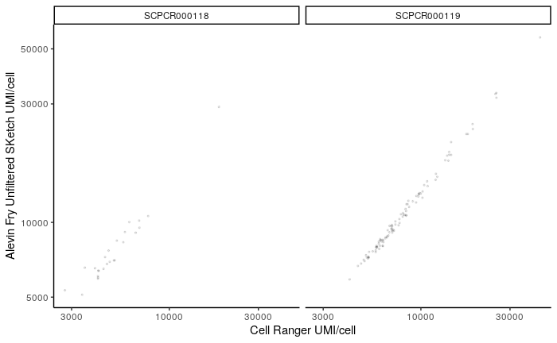

```r
ggplot(nucleus_qc_common_cor, aes(x = cellranger_cdnapre_mRNA, y = alevin_fry_unfiltered_sketch_spliced_intron_)) +
  geom_point(size = 0.5, alpha = 0.1) +
  facet_wrap(~ sample) +
  scale_x_log10() +
  scale_y_log10() +
  labs(x = "Cell Ranger UMI/cell", y = "Alevin Fry Unfiltered SKetch UMI/cell") +
  theme_classic()
```

So now we can see why these correlations are so off, especially for 118, there are very few shared cell barcodes.

[figure not shown]

Here you can see that for 119, Kallisto has generally much higher UMI/cell, but higher variance than Alevin-Fry-Unfiltered-Sketch.